# Analysis: Understanding Student Major Selection (STEM Focus)

05 September, 2019

# Introduction

### Goal

We are looking to understand the relationships between what major students choose and that student’s self-perception in additional to their demographic characteristics (which could potentially serve an latent variables for cultural percentions).

**Per the prompt:**

##### *Knowing more about the characteristics of students who choose STEM majors can help us predict how many students will choose those majors and support the students in those majors.*

### Assumptions Made

- That the surveys are based on ‘probability sample’. These are surveys where all units in our statistical population have a chance of being selected and the probability of selection is known to the researcher.
- That all students have the sample probability of being sampled because it is likely that this survey went out to all students
- That the survey questions had already been validated to be used for this population. (ie the scales have been validated)

### Design Decisions

At the end of this analysis, I wanted to produce a model that is reproducible and *extendable* to other datases.

- With reproducibility in mind, I chose to perform the analysis within R and to document the process as well as the findings within [RMarkdown](https://rmarkdown.rstudio.com/)
- Where possible, I have sought to make this analysis portable and extendable through the folder project structure and code structure

### Investigation Reason

If we can predict the major of the students and understand the driving factors there are a few actions that can be taken from the model:

1. Looking for what characteristics are *“valued” within the model*:
   - “Optimize Enrollment”: Ie accept more/less students who meet the model characteristics
   - Adjust resources based upon currently available data (ie might see that there is a bubble of STEM students coming which might require more lab space)
2. Looking for what characteristics that are *not “valued” within the model*:
   - Look to interview students who would have likely been within STEM, but due to a reason aren’t within STEM

# EDA

## Data Overview

Our data for this analysis came from two differnt sources:  
1. The surevy results provided by the IR team.  
- Students of the 2012, 2013, 2014, and 2015 freshman cohorts were surveyed during their second semester of their first year.  
2. The factbooks for the corresponding years

*Note: the factbooks were compiled from the Wake Forest Office of Institutional Research site [Link](https://ir.wfu.edu/)*

[figure not shown]

### Data imported and additional factors created

- For this dataset I decided to transform the scales of the questions to categorical data because I did not want to assume later on a consistent and proportional increase in value across the scale.
- In the review of the Race/Ethnicity distribution both witin the fact book as well as the survey response data, I found that ~90% of all students reported their ethnicty to be either White, Asian, or Hispanic/LatinX. Therefore I collapsed the remaining ethnicities within an “Other” group.
- I also decided to create a new variable called STEM, which output a YES/NO if the major for the student fell within the STEM category. This is benefitial when developing the initial model which seeks to provide a prediction of the student’s major being either STEM or non-STEM

```r
# Load data
suppressWarnings(suppressMessages(
WFU_stu <- readr::read_csv("./Data/data_for_interviewees.csv") %>%
  mutate_if(is.numeric,as.factor) %>%
  mutate(GENDER = trimws(toupper(GENDER)),
         COLLEGE_GPA = as.numeric(COLLEGE_GPA),
         COLLEGE_GPA = case_when(COLLEGE_GPA == 1 ~ 1,
                                 COLLEGE_GPA == 2 ~ 2,
                                 COLLEGE_GPA == 3 ~ 2.33,
                                 COLLEGE_GPA == 4 ~ 2.67,
                                 COLLEGE_GPA == 5 ~ 3.0,
                                 COLLEGE_GPA == 6 ~ 3.33,
                                 COLLEGE_GPA == 7 ~ 3.67,
                                 COLLEGE_GPA == 8 ~ 4,
                                 TRUE ~ 0),
         HS_GPA = as.numeric(HS_GPA),
         HS_GPA = case_when(HS_GPA == 1 ~ 1,
                            HS_GPA == 2 ~ 2,
                            HS_GPA == 3 ~ 2.33,
                            HS_GPA == 4 ~ 2.67,
                            HS_GPA == 5 ~ 3.0,
                            HS_GPA == 6 ~ 3.33,
                            HS_GPA == 7 ~ 3.67,
                            HS_GPA == 8 ~ 4,
                            TRUE ~ 0),
         DISTANCE = as.numeric(DISTANCE),
         DISTANCEval = case_when(DISTANCE == 1 ~ 5,
                                 DISTANCE == 2 ~ 10,
                                 DISTANCE == 3 ~ 50,
                                 DISTANCE == 4 ~ 100,
                                 DISTANCE == 5 ~ 500,
                                 DISTANCE == 6 ~ 1000,
                                 TRUE ~ 0),
         STEM = case_when(MAJOR == 6 ~"YES", TRUE ~ "NO"),
         STEM = as.factor(STEM)) %>%
  mutate(COLLEGE_GPA = ifelse(COLLEGE_GPA == 0, NA, COLLEGE_GPA),
         HS_GPA = ifelse(HS_GPA == 0, NA, HS_GPA),
         DISTANCEval = ifelse(DISTANCEval == 0, NA, DISTANCEval)) %>%
  ungroup()
))
# xtabs(~RACETHN + GENDER, data=WFU_stu)

WFU_stu <-
  WFU_stu %>% mutate(RACEgroup = fct_collapse(RACETHN, "Other" = c("1", "3", "5", "7"),
                                              "Asian" = c("2"),
                                              "LatinX" = c("4"),
                                              "White" = c("6")))



# xtabs(~RACEgroup, data=WFU_stu)

# > colnames(WFU_stu)
#  [1] "STUID"       "YEAR"        "GENDER"      "RACETHN"     "MAJOR"       "DISTANCE"    "HS_GPA"      "COLLEGE_GPA" "FIRST_GEN"   "ACT01"       "ACT02"       "ACT03"       "ACT04"       "ACT05"
# [15] "ACT06"       "ACT07"       "ACT08"       "ACT09"       "ACT10"       "ACT11"       "ACT12"       "ACT13"       "RATE1"       "RATE2"       "RATE3"       "RATE4"       "RATE5"       "RATE6"
# [29] "RATE7"       "AGREE_01"    "AGREE_02"    "AGREE_03"    "AGREE_04"    "AGREE_05"    "AGREE_06"    "AGREE_07"    "AGREE_08"    "AGREE_09"


EthLook <- readxl::read_excel("./Data/DataFromFactBooks.xlsx", sheet = "LookUp")

suppressWarnings(suppressMessages(
FB <- readxl::read_excel("./Data/DataFromFactBooks.xlsx", sheet = "FC_Data") %>%
  gather(3:9, key= "year",value="StuCount") %>%
  mutate(year = as.numeric(year),
         Gender= trimws(toupper(Gender))) %>%
  mutate_if(is.numeric, replace_na, 0) %>%
  left_join(., EthLook) %>%
  mutate(ID = as_factor(ID),
    RACEgroup = fct_collapse(ID, "Other" = c("-1","1", "3", "5", "7"),
                                              "Asian" = c("2"),
                                              "LatinX" = c("4"),
                                              "White" = c("6")))
))


suppressWarnings(suppressMessages(
WFU_stu %>% group_by(YEAR) %>% summarise(CountStu_response = n()) %>%
  left_join(.,
            (FB %>% mutate(year = as_factor(year)) %>% group_by(year) %>% summarise(TotalStu = sum(StuCount, na.rm=TRUE))),
            by= c("YEAR" = "year")) %>%
  mutate(PercentResponse = CountStu_response/TotalStu) %>%
  mutate(PercentResponse = scales::percent(PercentResponse)) %>%
  kable(align='c') %>%
  kable_styling(bootstrap_options = c("striped", "hover", "condensed", full_width = F))
))
```

| YEAR | CountStu_response | TotalStu | PercentResponse |
| --- | --- | --- | --- |
| 2012 | 513 | 1234 | 41.6% |
| 2013 | 594 | 1230 | 48.3% |
| 2014 | 395 | 1287 | 30.7% |
| 2015 | 498 | 1284 | 38.8% |

```r
# FB %>% group_by(RACEgroup, Gender) %>% summarise(stuCnt = sum(StuCount)) %>% spread(Gender, value=stuCnt)
```

Asking questions along the way in our investigation:  
* What happened within 2014 where the respose rate was substantially lower than the other years

### Overview of the provided dataset

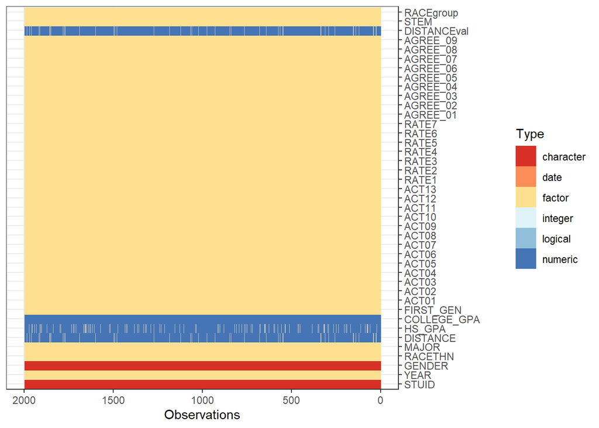

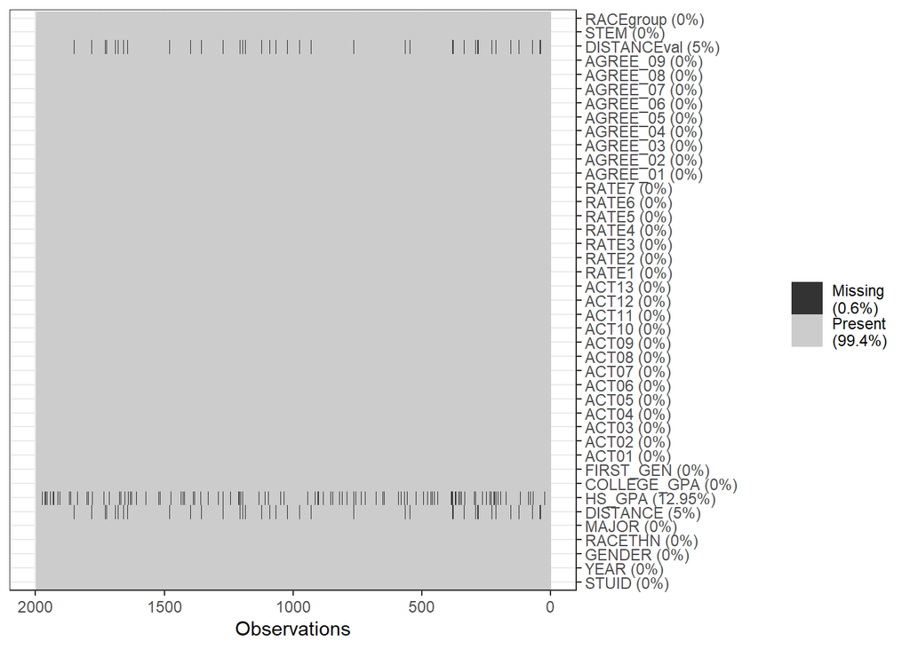

```r
visdat::vis_dat(WFU_stu, sort_type = FALSE, palette = "cb_safe") +
  coord_flip() +
  theme_bw()

visdat::vis_miss(WFU_stu) + coord_flip() + theme_bw()
```

## Demographic Comparison

**Compare survey response to student population using WFU fact book**

Goal is to see if the students who responded are a representative sample of the student body.

Potentaially could use a “rank-sum test”

chi.square vs an anova for this analysis

Decided to use a Chi-square test to understand if distribution of the students who responded to the survey matches the student population as reflected within the WFU fact book for that year.

### Chi-Square: Gender + Race/Ethnicity

**Looking into the comparison of gender and ethnicity**

```r
WFU_Resp <- WFU_stu %>%
  group_by(GENDER, RACEgroup) %>% summarise(CountStu_Samp = n()) %>%
  ungroup() %>%
  mutate(Samp_Perc = CountStu_Samp/sum(CountStu_Samp))


TotalPop <- FB %>% filter(year <= 2015) %>% group_by(Gender, RACEgroup) %>%
  summarise(CountStu_Pop = sum(StuCount, na.rm = TRUE)) %>%
  ungroup() %>%
  mutate(Pop_Perc = CountStu_Pop/sum(CountStu_Pop))

ComparSamp <- left_join(TotalPop, WFU_Resp,
                        by = c("Gender" = "GENDER", "RACEgroup" = "RACEgroup")) %>%
  mutate_if(is.numeric, replace_na, 0) %>%
  mutate(NonRep_wt = Pop_Perc/Samp_Perc)

ComparSamp %>%
  kable(align='c') %>%
  kable_styling(bootstrap_options = c("striped", "hover", "condensed", full_width = F))
```

| Gender | RACEgroup | CountStu_Pop | Pop_Perc | CountStu_Samp | Samp_Perc | NonRep_wt |
| --- | --- | --- | --- | --- | --- | --- |
| FEMALE | Other | 247 | 0.0490566 | 115 | 0.0575 | 0.8531583 |
| FEMALE | Asian | 300 | 0.0595829 | 145 | 0.0725 | 0.8218334 |
| FEMALE | LatinX | 199 | 0.0395233 | 118 | 0.0590 | 0.6698871 |
| FEMALE | White | 1903 | 0.3779543 | 821 | 0.4105 | 0.9207170 |
| MALE | Other | 228 | 0.0452830 | 83 | 0.0415 | 1.0911571 |
| MALE | Asian | 242 | 0.0480636 | 99 | 0.0495 | 0.9709809 |
| MALE | LatinX | 155 | 0.0307845 | 61 | 0.0305 | 1.0093281 |
| MALE | White | 1761 | 0.3497517 | 558 | 0.2790 | 1.2535905 |

```r
chisq.test(ComparSamp$CountStu_Samp, p = ComparSamp$Pop_Perc)
```

```
##
##  Chi-squared test for given probabilities
##
## data:  ComparSamp$CountStu_Samp
## X-squared = 62.656, df = 7, p-value = 4.442e-11
```

```r
## with a p-value ~0, means that the sample distribution doesn't match the population



GEN_ETH_wt <- ComparSamp %>% select(Gender, RACEgroup, NonRep_wt)
```

Here, as with the two tests below, we find that the sample does not fully represent the student population.

### Chi-Square: Gender

**Performing a chi-square test on the response counts of different genders**

```r
#chi square test for gender...
WFU_Resp <- WFU_stu %>%
  group_by(GENDER) %>% summarise(CountStu_Samp = n()) %>%
  ungroup() %>%
  mutate(Samp_Perc = CountStu_Samp/sum(CountStu_Samp))

TotalPop <- FB %>% filter(year <= 2015) %>% group_by(Gender) %>%
  summarise(CountStu_Pop = sum(StuCount, na.rm = TRUE)) %>%
  ungroup() %>%
  mutate(Pop_Perc = CountStu_Pop/sum(CountStu_Pop))

ComparSamp <- left_join(TotalPop, WFU_Resp,
                        by = c("Gender" = "GENDER")) %>%
  mutate_if(is.numeric, replace_na, 0) %>%
  mutate(NonRep_wt = Pop_Perc/Samp_Perc)

ComparSamp %>%
  kable(align='c') %>%
  kable_styling(bootstrap_options = c("striped", "hover", "condensed", full_width = F))
```

| Gender | CountStu_Pop | Pop_Perc | CountStu_Samp | Samp_Perc | NonRep_wt |
| --- | --- | --- | --- | --- | --- |
| FEMALE | 2649 | 0.5261172 | 1199 | 0.5995 | 0.8775933 |
| MALE | 2386 | 0.4738828 | 801 | 0.4005 | 1.1832280 |

```r
chisq.test(ComparSamp$CountStu_Samp, p= ComparSamp$Pop_Perc)
```

```
##
##  Chi-squared test for given probabilities
##
## data:  ComparSamp$CountStu_Samp
## X-squared = 43.198, df = 1, p-value = 4.947e-11
```

```r
## with a p-value ~0, means that the sample distribution doesn't match the population
```

With a low p-value the Chi-square test, we reject the null hypothesis and determine that the survey response does not match the proportions of the student population for gender.

### Chi-Square: Race/Ethnicity

**Looking at the ethnicity comparison**

```r
WFU_Resp <- WFU_stu %>%
  group_by(RACEgroup) %>% summarise(CountStu_Samp = n()) %>%
  ungroup() %>%
  mutate(Samp_Perc = CountStu_Samp/sum(CountStu_Samp),
         RACEgroup = RACEgroup)


TotalPop <- FB %>% filter(year <= 2015) %>% group_by(RACEgroup) %>%
  summarise(CountStu_Pop = sum(StuCount, na.rm = TRUE)) %>%
  ungroup() %>%
  mutate(Pop_Perc = CountStu_Pop/sum(CountStu_Pop))

ComparSamp <- left_join(TotalPop, WFU_Resp,
                        by = c("RACEgroup" = "RACEgroup")) %>%
  mutate_if(is.numeric, replace_na, 0) %>%
  mutate(NonRep_wt = Pop_Perc/Samp_Perc)

ComparSamp %>%
  kable(align='c') %>%
  kable_styling(bootstrap_options = c("striped", "hover", "condensed", full_width = F))
```

| RACEgroup | CountStu_Pop | Pop_Perc | CountStu_Samp | Samp_Perc | NonRep_wt |
| --- | --- | --- | --- | --- | --- |
| Other | 475 | 0.0943396 | 198 | 0.0990 | 0.9529255 |
| Asian | 542 | 0.1076465 | 244 | 0.1220 | 0.8823482 |
| LatinX | 354 | 0.0703078 | 179 | 0.0895 | 0.7855625 |
| White | 3664 | 0.7277061 | 1379 | 0.6895 | 1.0554113 |

```r
chisq.test(ComparSamp$CountStu_Samp, p = ComparSamp$Pop_Perc)
```

```
##
##  Chi-squared test for given probabilities
##
## data:  ComparSamp$CountStu_Samp
## X-squared = 18.778, df = 3, p-value = 0.0003039
```

Chi-square would indicate that the survey response does not match the proportions of the student population for Ethnicity

## Non-response weights

By comparing the sample proportions to the population within the factbooks via a Chi-Square test we find that the __sample does not align with the _population.__

This misalignment is due to non-response, and from calculating the non-response weight (NonRep_wt) we see that:  
- Males for every ethnicity except for Asian responsed at a lower rate than the population (weight is >1)  
- For all females we see that their response rate was higher than that of the population (weight is <1)

We will use these weights when reviewing our descriptive stats.

```r
GEN_ETH_wt %>%
  arrange(desc(NonRep_wt)) %>%
  round_df(., 3) %>%
  kable(align='c') %>%
  kable_styling(bootstrap_options = c("striped", "hover", "condensed", full_width = F))
```

| Gender | RACEgroup | NonRep_wt |
| --- | --- | --- |
| MALE | White | 1.254 |
| MALE | Other | 1.091 |
| MALE | LatinX | 1.009 |
| MALE | Asian | 0.971 |
| FEMALE | White | 0.921 |
| FEMALE | Other | 0.853 |
| FEMALE | Asian | 0.822 |
| FEMALE | LatinX | 0.670 |

## STEM vs Rest Respondents

Below is an comparison of the count of students who fall within each category.

When we consider the responses to the serveys, we are assuming that the scales have been validated and the questions have been written to produce the least amount of bias.

### Compare response rates

**Demographic overview**

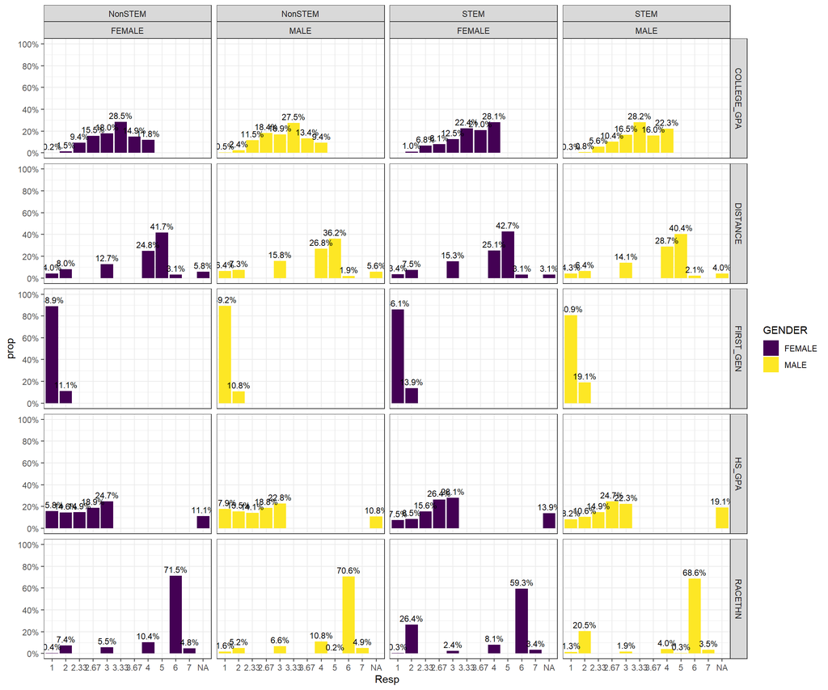

```r
WFU_stu %>%
  select(1:9) %>% mutate(STEM = case_when(MAJOR == 6 ~ "STEM", TRUE ~ "NonSTEM")) %>%
  select(-MAJOR) %>%
  gather(-STUID, -YEAR, -GENDER, -STEM, key = "var", value = "Resp") %>%
  ggplot(aes(group = GENDER, x = Resp)) +
    geom_bar(aes(y = ..prop.., fill = GENDER), stat="count") +
    geom_text(aes(label = scales::percent(..prop..),
                   y= ..prop.. ), stat= "count", vjust = -.5, size=3) +
    theme_bw()+
    scale_fill_viridis(discrete=TRUE) +
    facet_grid(var ~ STEM+GENDER) +
    scale_y_continuous(labels = scales::percent_format(accuracy = 1), breaks=seq(0, 1, by=0.2)) +
    expand_limits(y=c(0,1))
```

**Responses to ACT Questions** These questions asked students about the frequency at which they performed certain activities in the past year.

**Scale**

1: Not at all  
2: Occasionally  
3: Frequently

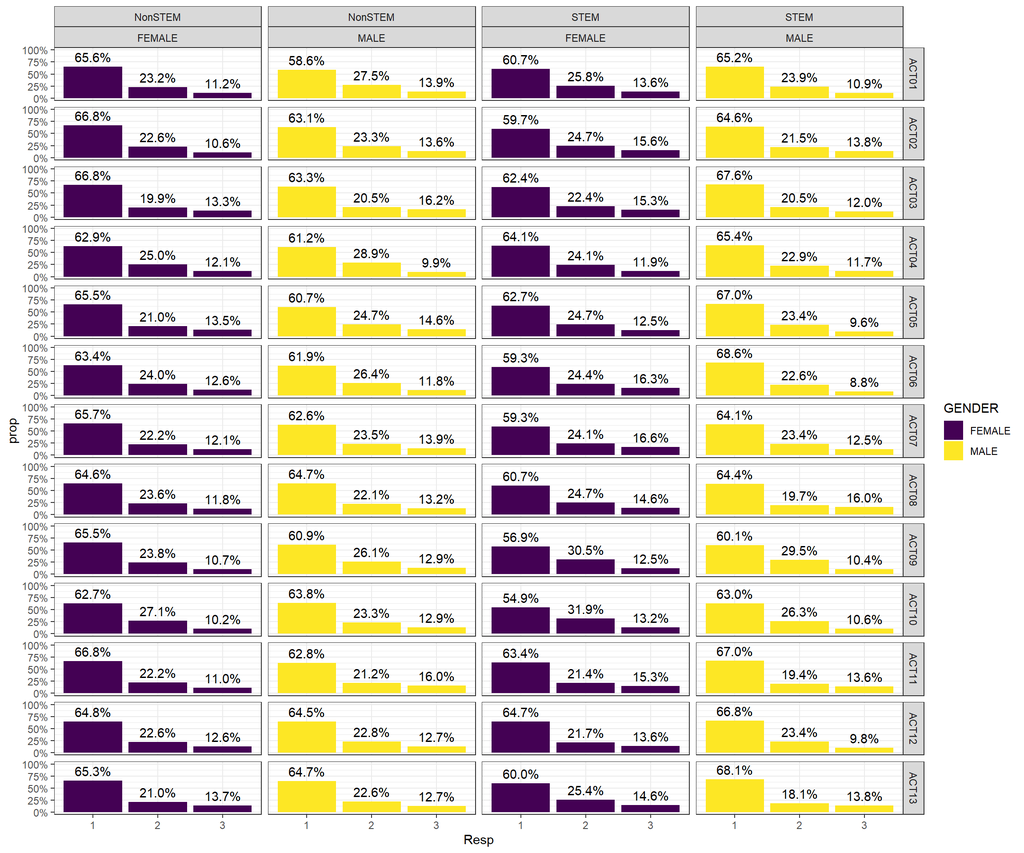

```r
WFU_stu %>%
  mutate(STEM = case_when(MAJOR == 6 ~ "STEM", TRUE ~ "NonSTEM")) %>%
  select(STUID, YEAR, GENDER, STEM, contains("ACT")) %>%
  gather(-STUID, -YEAR, -GENDER, -STEM, key = "var", value = "Resp") %>%
  ggplot(aes(group = GENDER, x = Resp)) +
    geom_bar(aes(y = ..prop.., fill = GENDER), stat="count") +
    geom_text(aes(label = scales::percent(..prop..),
                   y= ..prop.. ), stat= "count", vjust = -.5) +
    theme_bw()+
    scale_fill_viridis(discrete=TRUE) +
    facet_grid(var ~ STEM+GENDER) +
    scale_y_continuous(labels = scales::percent_format(accuracy = 1), limits = c(0, 1))+
    expand_limits(y=c(0,1))
```

**Responses to RATE Questions**

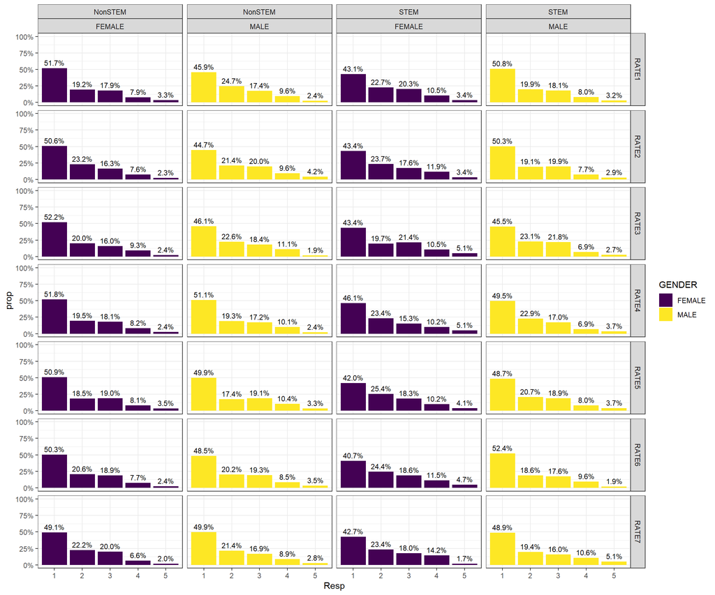

```r
WFU_stu %>%
  mutate(STEM = case_when(MAJOR == 6 ~ "STEM", TRUE ~ "NonSTEM")) %>%
  select(STUID, YEAR, GENDER, STEM, contains("RATE")) %>%
  gather(-STUID, -YEAR, -GENDER, -STEM, key = "var", value = "Resp") %>%
  ggplot(aes(group = GENDER, x = Resp)) +
    geom_bar(aes(y = ..prop.., fill = GENDER), stat="count") +
    geom_text(aes(label = scales::percent(..prop..),
                   y= ..prop.. ), stat= "count", vjust = -.5, size=3) +
    theme_bw()+
    scale_fill_viridis(discrete=TRUE) +
    facet_grid(var ~ STEM+GENDER) +
    scale_y_continuous(labels = scales::percent_format(accuracy = 1), limits = c(0, 1))+
    expand_limits(y=c(0,1))
```

**Responses to AGREE Questions**

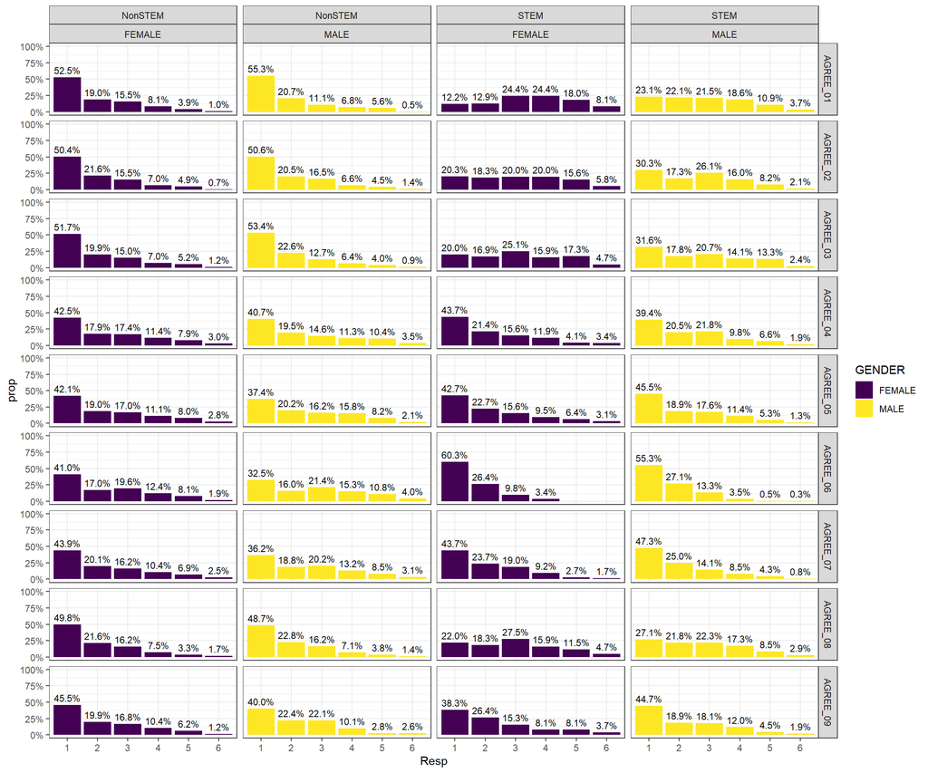

```r
WFU_stu %>%
  mutate(STEM = case_when(MAJOR == 6 ~ "STEM", TRUE ~ "NonSTEM")) %>%
  select(STUID, YEAR, GENDER, STEM, contains("AGREE")) %>%
  gather(-STUID, -YEAR, -GENDER, -STEM, key = "var", value = "Resp") %>%
  ggplot(aes(group = GENDER, x = Resp)) +
    geom_bar(aes(y = ..prop.., fill = GENDER), stat="count") +
    geom_text(aes(label = scales::percent(..prop..),
                   y= ..prop.. ), stat= "count", vjust = -.5, size=3) +
    theme_bw()+
    scale_fill_viridis(discrete=TRUE) +
    facet_grid(var ~ STEM+GENDER) +
    scale_y_continuous(labels = scales::percent_format(accuracy = 1), limits = c(0, 1))+
    expand_limits(y=c(0,1))
```

## Determine if Missingness Matters

From the missingness review. It looks like only a how far a student is from home and their HS GPA has NA’s

Is it possible that a certain subset of students chose not to respond with their HS GPA?

# Model

## Develop Model for Major

Will probably start with logistic regression and then potentially move on to a more complicated model.

Largely looking for a classification for determining the **MAJOR** based on the survey results.

What models were chosen?

What are these types of models?

```r
WFU_model <- WFU_stu %>%
  # mutate(STEM = case_when(MAJOR == 6 ~"YES", TRUE ~ "NO")) %>%
  # select(-MAJOR, -STUID, -YEAR, -DISTANCE, -HS_GPA) %>%
  select(STEM, GENDER, RACEgroup, COLLEGE_GPA, FIRST_GEN,
         ACT09, ACT12, ACT13,
         RATE5, RATE7,
         AGREE_01, AGREE_02, AGREE_03, AGREE_08, AGREE_06
         ) %>%
  mutate(GENDER = as_factor(GENDER),
         STEM = as_factor(STEM))

# Using tidymodels structure ---------

train_test_split <-
  rsample::initial_split(
    data = WFU_model,
    prop = 0.80
  )

# train_test_split

train_tbl <- train_test_split %>% training()
test_tbl  <- train_test_split %>% testing()
```

## Logistic Regression

```r
recipe_prepped <- recipe_simple(dataset = train_tbl)

train_baked <- bake(recipe_prepped, new_data = train_tbl)
test_baked  <- bake(recipe_prepped, new_data = test_tbl)


# logGLM <- glm(STEM ~  ., data=train_baked, family="binomial")

logistic_glm <-
  logistic_reg(mode = "classification") %>%
  set_engine("glm") %>%
  fit(STEM ~ ., data = train_baked)

# logistic_glm

predictions_glm <- logistic_glm %>%
  predict(new_data = test_baked) %>%
  bind_cols(test_baked %>% select(STEM))




predictions_glm %>%
  metrics(STEM, .pred_class) %>%
  select(-.estimator) %>%
  filter(.metric == "accuracy") %>%
    round_df(., 3)
```

| .metric | .estimate |
| --- | --- |
| accuracy | 0.9 |

```r
# Precision shows how sensitive models are to False Positives (i.e. predicting a customer is leaving when he-she is actually staying) whereas
# Recall looks at how sensitive models are to False Negatives (i.e. forecasting that a customer is staying whilst he-she is in fact leaving).

tibble(
  "precision" =
    precision(predictions_glm, STEM, .pred_class) %>%
    select(.estimate),
  "recall" =
    recall(predictions_glm, STEM, .pred_class) %>%
    select(.estimate)
) %>%
  unnest() %>%
  round_df(., 3) %>%
  kable(align='c') %>%
  kable_styling(bootstrap_options = c("striped", "hover", "condensed", full_width = F))
```

| precision | recall |
| --- | --- |
| 0.913 | 0.941 |

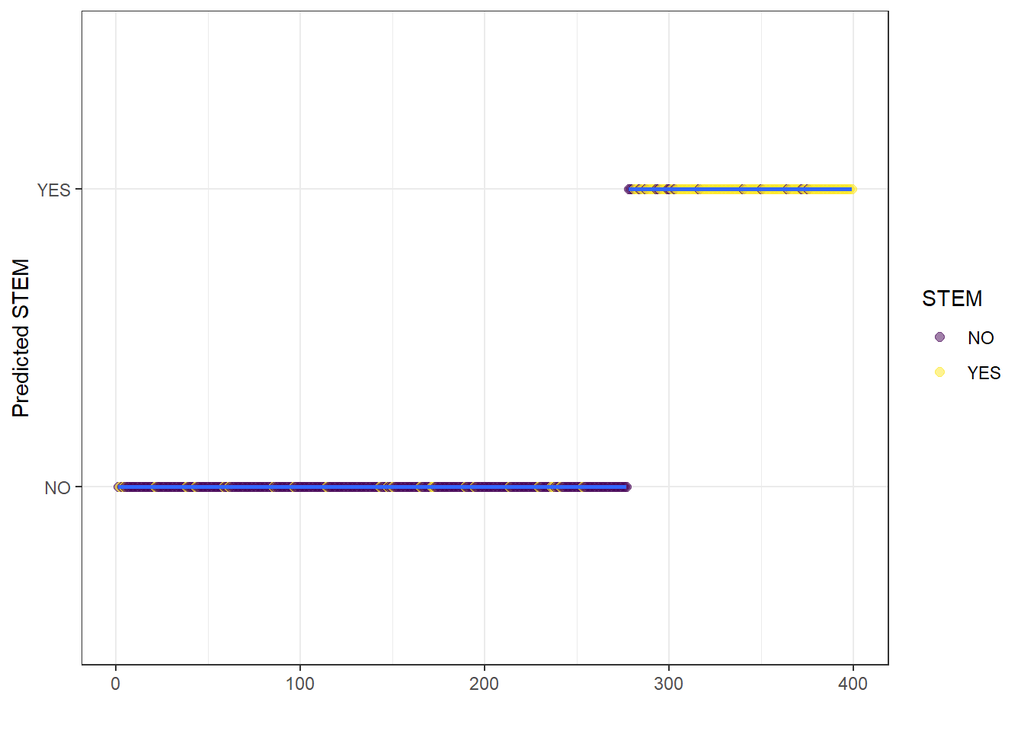

```r
predictions_glm %>% arrange(.pred_class) %>%  mutate(ord = row_number()) %>%
  ggplot(aes(x=ord, y=.pred_class))+
    geom_point(aes(color=STEM), size =2, alpha = .5)+
    geom_smooth(method="glm")+
    ylab("Predicted STEM")+
    xlab("")+
    theme_bw()+
    viridis::scale_color_viridis(discrete=TRUE)
```

utilizing odds ratio to interpret the elements of the logisitic model

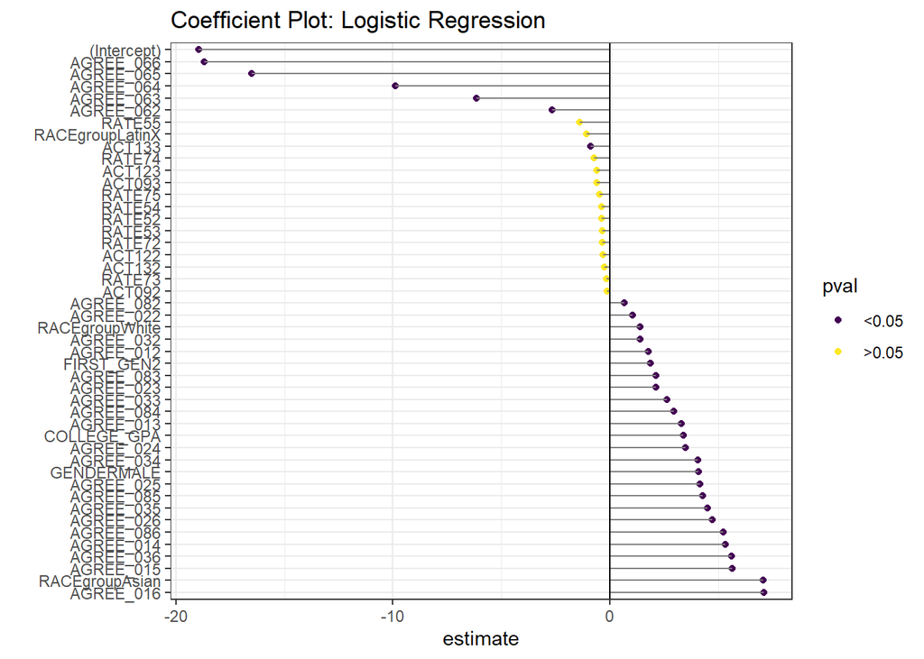

```r
tidy(logistic_glm) %>%
  mutate(pval = case_when(p.value < 0.05 ~ "<0.05", TRUE ~ ">0.05"),
         LogOdds = exp(estimate)) %>%
  arrange(desc(abs(LogOdds))) %>%
    round_df(3) %>%
  ggplot(aes(x=fct_reorder(term, desc(estimate)), y=estimate))+
    geom_point(aes(color=pval))+
    geom_segment(aes(x = term, y = 0, xend = term, yend = estimate), color = "grey50") +
    geom_hline(yintercept = 0)+
    coord_flip()+
    theme_bw()+
    viridis::scale_color_viridis(discrete = TRUE)+
    xlab("")+
    ggtitle("Coefficient Plot: Logistic Regression")
```

```r
glm_tbl <- tidy(logistic_glm) %>%
  mutate(pval = case_when(p.value < 0.05 ~ "<0.05", TRUE ~ ">0.05"),
         Odds = exp(estimate)) %>%
  rename(LogOdds = estimate) %>%
  arrange(desc(abs(Odds))) %>%
    round_df(2) %>%
  kable(align='c') %>%
  kable_styling(bootstrap_options = c("striped", "hover", "condensed", full_width = F))

# the odds of getting into an honors class for females (female = 1)over the odds of getting into an honors class for males (female = 0) is exp(.979948) = 2.66.

# the odds of
```

## Random Forest

Utilizing a random forest model to classify if a student will be graduating within a STEM major or not.

```r
# WFU_RF <- WFU_stu %>%
#   # mutate(STEM = case_when(MAJOR == 6 ~"YES", TRUE ~ "NO")) %>%
#   select(-MAJOR, -STUID, -YEAR, -DISTANCE, -HS_GPA, -RACETHN, -DISTANCEval) %>%
#   # select(STEM, GENDER, RACETHN, COLLEGE_GPA, FIRST_GEN, ACT09, ACT12, ACT13, RATE5, RATE7, AGREE_01, AGREE_02, AGREE_03, AGREE_08) %>%
#   mutate(GENDER = as_factor(GENDER),
#          STEM = as_factor(STEM))
#
# rf_train_test_split <-
#   rsample::initial_split(
#     data = WFU_RF,
#     prop = 0.80
#   )
#
# # train_test_split
#
# rf_train_tbl <- rf_train_test_split %>% training()
# rf_test_tbl  <- rf_train_test_split %>% testing()
#
# rf_recipe_prepped <- recipe_simple(dataset = rf_train_tbl)
#
# rf_train_baked <- bake(recipe_prepped, new_data = rf_train_tbl)
# rf_test_baked  <- bake(recipe_prepped, new_data = rf_test_tbl)

rf_build <-
  rand_forest(trees = 1000, mtry = 6, mode = "classification") %>%
  set_engine("randomForest", importance=T, localImp = T) %>%
  fit(STEM ~ ., data = train_baked)


predictions_rf <- rf_build %>%
  predict(new_data = test_baked) %>%
  bind_cols(test_baked %>% select(STEM))


predictions_rf %>%
  metrics(STEM, .pred_class) %>%
  select(-.estimator) %>%
  filter(.metric == "accuracy") %>%
    round_df(., 3) %>%
  kable(align='c') %>%
  kable_styling(bootstrap_options = c("striped", "hover", "condensed", full_width = F))
```

| .metric | .estimate |
| --- | --- |
| accuracy | 0.86 |

```r
# impt_frame <- measure_importance(rf_build$fit)
#
# plot_multi_way_importance(impt_frame, no_of_labels = 10)
# plot_multi_way_importance(impt_frame, x_measure = "accuracy_decrease", y_measure = "gini_decrease", size_measure = "p_value", no_of_labels = 10)
#
#
# #variable depth
# md_frame <- min_depth_distribution(rf_build$fit)
#
# plot_min_depth_distribution(md_frame, mean_sample = "top_trees") # default mean_sample arg
```

## Confuson Matrices

The confusion matrix allows us to show based on the test data how often we are correctly predicting each category.

When we compare the logistic regression vs the random forest we see that the **logistic regression** model performs better than the random forest model. The logistic regession model also had the added benefit of being significantly easier to interpret than the random forest.

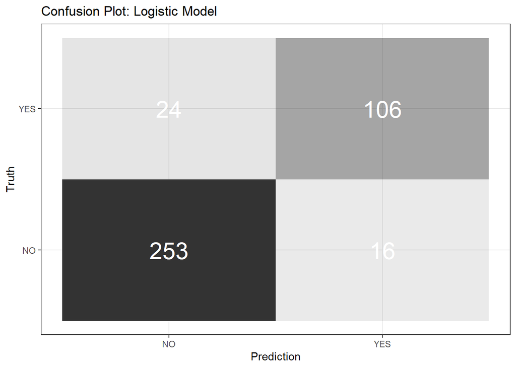

```r
# Confusion matrix for Logistic
predictions_glm %>%
  conf_mat(STEM, .pred_class) %>%
  pluck(1) %>%
  as_tibble() %>%
  ggplot(aes(Prediction, Truth, alpha = n)) +
  geom_tile(show.legend = FALSE) +
  geom_text(aes(label = n), colour = "white", alpha = 1, size = 8)+
  theme_bw()+
  ggtitle("Confusion Plot: Logistic Model")
```

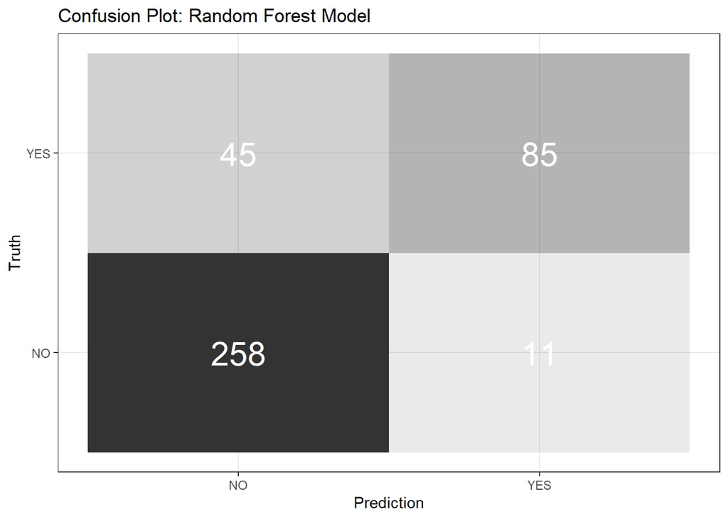

```r
# Confusion matrix for RF
predictions_rf %>%
  conf_mat(STEM, .pred_class) %>%
  pluck(1) %>%
  as_tibble() %>%
  ggplot(aes(Prediction, Truth, alpha = n)) +
  geom_tile(show.legend = FALSE) +
  geom_text(aes(label = n), colour = "white", alpha = 1, size = 8)+
  theme_bw()+
  ggtitle("Confusion Plot: Random Forest Model")
```

# Takeaways/ Application

Our goal was to be able to utilize the survey data to be able to predict if a student will choose to graduate within a STEM major  
* Depends on the student’s demographic information * In addition to how the students perceive themselves (as measured via the survey responses)

So that are the type of students who are more likely to choose STEM as their major?… They are more likely to be **male**, **white** or **asian**, have a fairly high gpa, believe themselves to be part of a scientific community

## Where to next

Has the amount of STEM majors been changing over time?

Seeing that “College GPA” has a fairly large impact in the model, a next step in this investigation would be to see if the types of classes that students took impacted their GPA.

## Limitations

- Did not investigate the characterize the students who were admitted but did not enroll, which could be an opportunity to quickly increase the STEM enrollment
- Did not review the students who changed their major later in their academic career, which could be used a test cases for how to transition the current population into STEM
- Data doesn’t show which students graduate within STEM. THis would help to understand if the support structure could be improved for those majors.
- Assuming that the count of students from the fact book are representative of students from the survery (start of year vs 2nd semester)
- Survey response distribution does not match with the student population

Leading vs lagging predictors

A work by [Phil Walker](https://github.com/phildwalker)

*philwalker2012@gmail.com*